# Astroestadística

José Eduardo Reyes Alvarado

16-Junio-2023

# Proyecto de Ciencia de Datos (Fase 3)

Importamos nuestros datos

```r
datos_sl <- rio::import("AirQualityUCI.xlsx")
```

Realizo el mismo tratamiento de los nombres de las columnas que hicce en la Fase 2. Además, he decidido en esta ocasión dejar la columna correspondiente a las lecturas de Benceno de la estación de referencia para verificar si es posible estimar la cantidad de esta sustancia presente en la atmósfera a partir de las concentraciones del resto de sustancias.

```r
datos_sl <- datos_sl[, c(4, 3, 7, 5, 9, 8, 11, 10, 6)]
colnames(datos_sl) <- c("CO", "CO_r", "NMHC", "NMHC_r", "NOx", "NOx_r", "NO2", "NO2_r", "Benceno")
```

Los registros faltantes están indicados con el valor -200. Voy a reemplazarlos con NA para poder hacer un análisis más detallado.

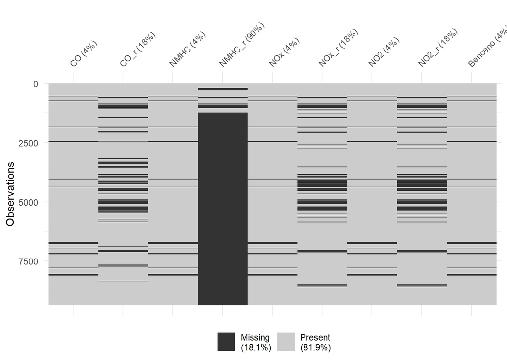

```r
#install packages(naniar)
library(naniar)
datos_sp <- datos_sl
datos_sp[datos_sp == -200] <- NA
vis_miss(datos_sp)
```

Como podemos ver, la columna perteneciente a los Hidrocarburos No Metánicos de referencia tienen una importante cantidad de datos faltantes, por lo que voy a eliminarla. Además, al eliminar esta columna, también quitaré los datos del sensor, pues en el análisis que haré más adelante pierde sentido contar únicamente con los datos del sensor.

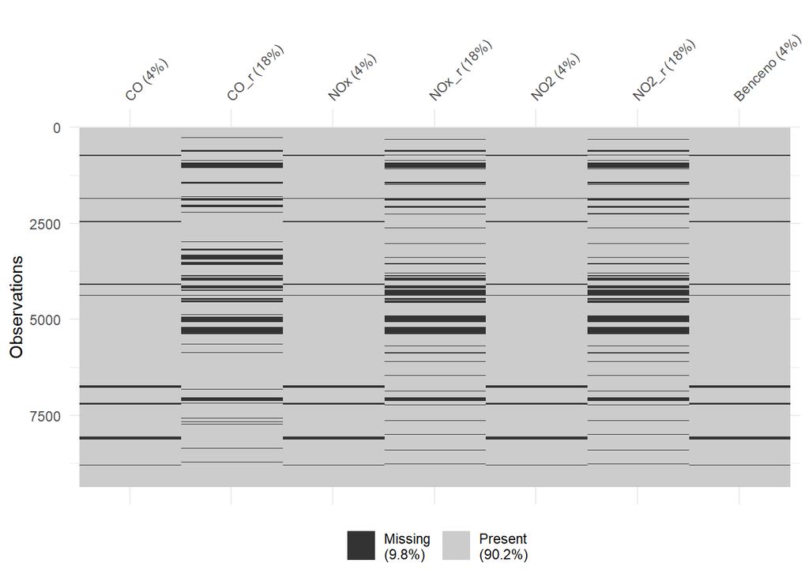

```r
datos_sp <- datos_sp[, -c(3, 4)]
vis_miss(datos_sp)
```

Ahora verificamos cuantos datos perderíamos si quitamos los valores faltantes.

```r
datos_sp_1 <- na.omit(datos_sp)
```

Con esto elimino el 25.82% de los datos, por lo que se cumple el requisito de no eliminar más del 30% de los datos.

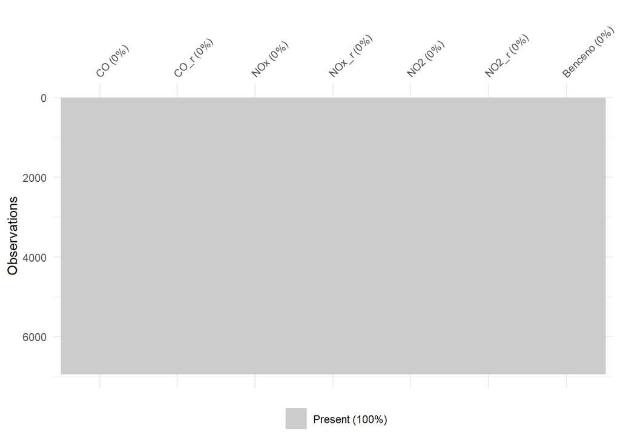

```r
vis_miss(datos_sp_1)
```

La gráfica anterior nos muestra que, efectivamente, ya no tenemos datos faltantes.

Ahora analizamos la distribución de los datos para todas las columnas.

Verifiquemos que tanto se parecen los datos a una distribución normal con ayuda de la función qqnorm

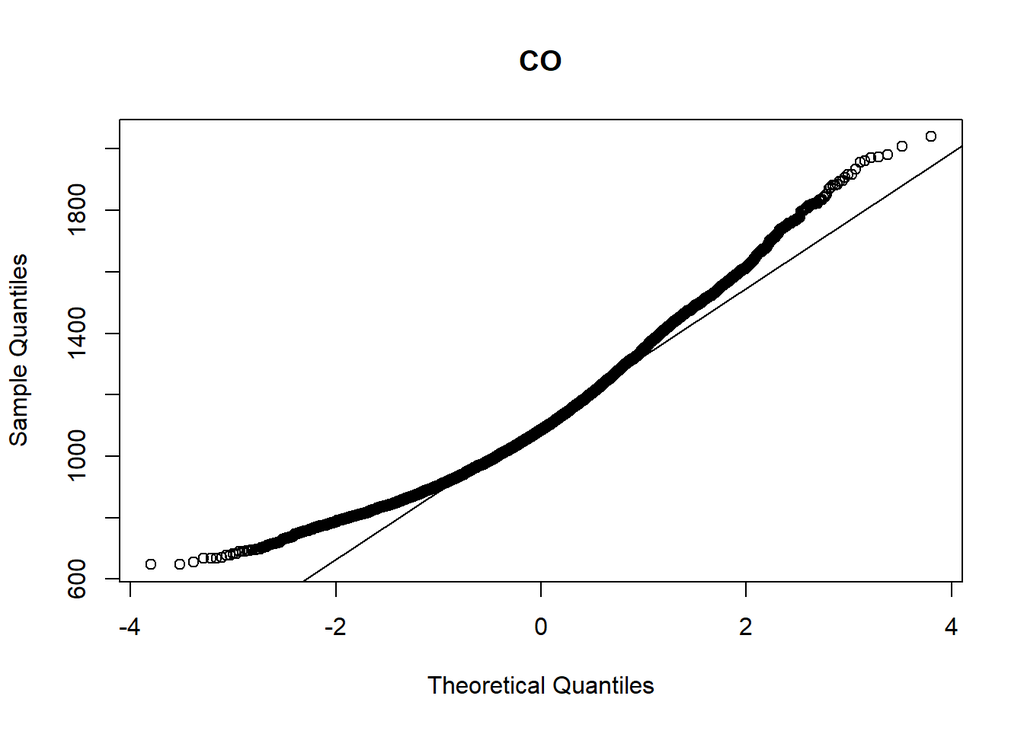

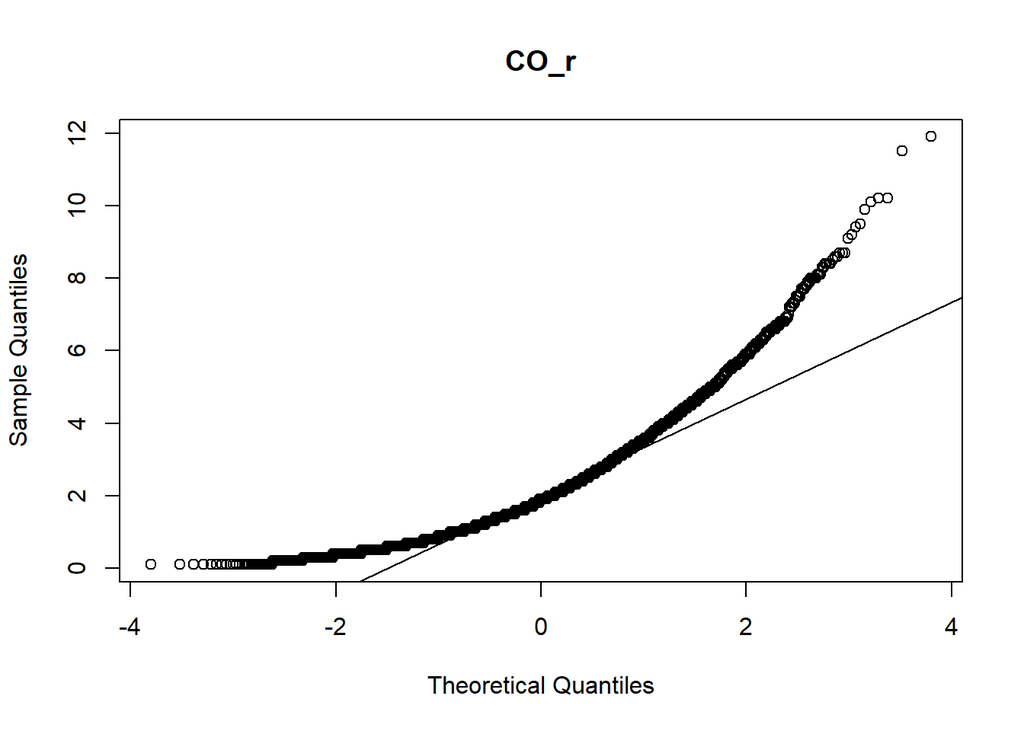

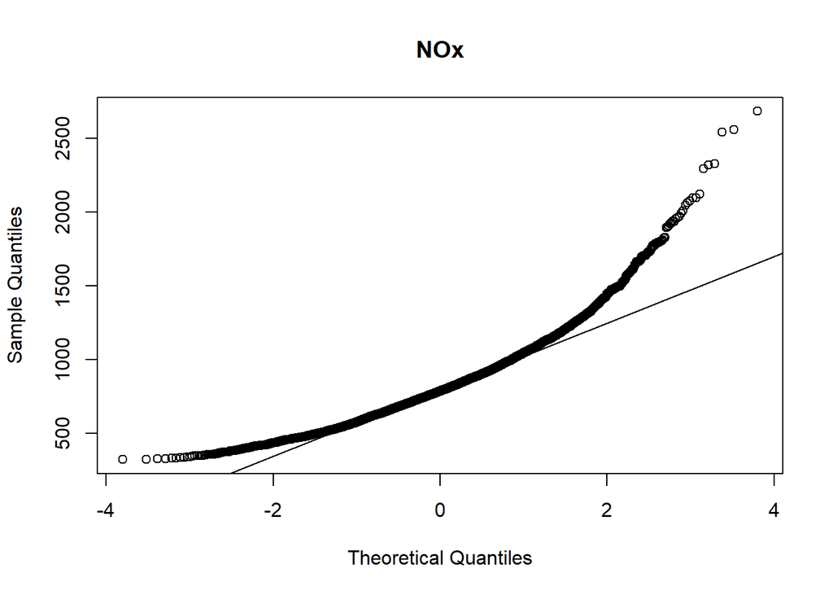

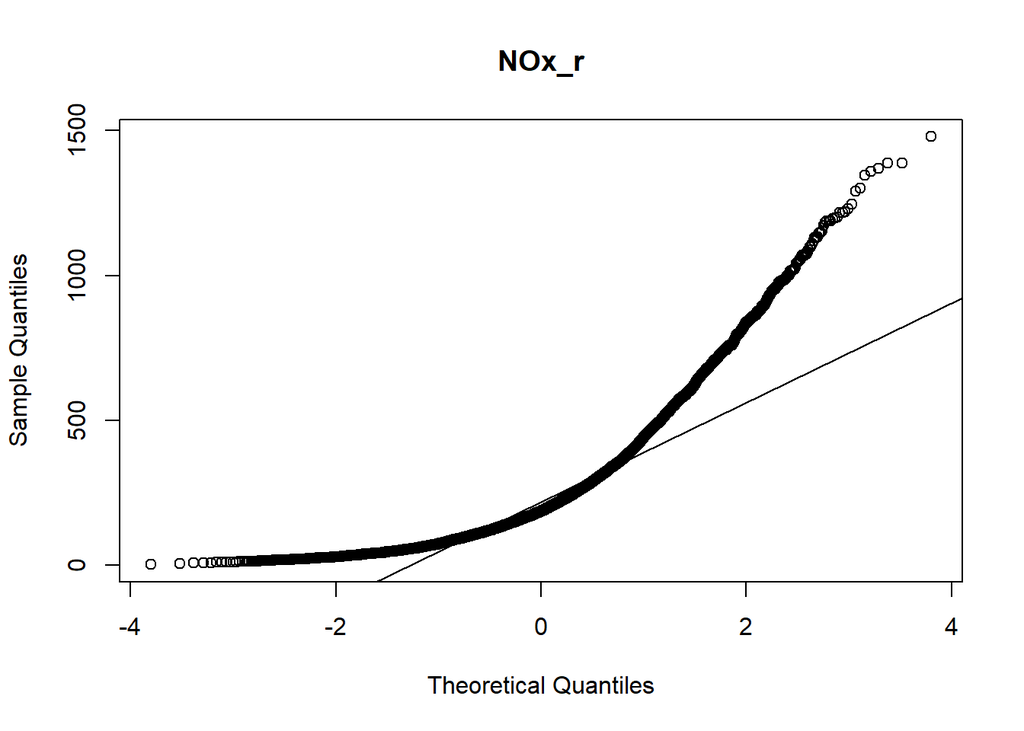

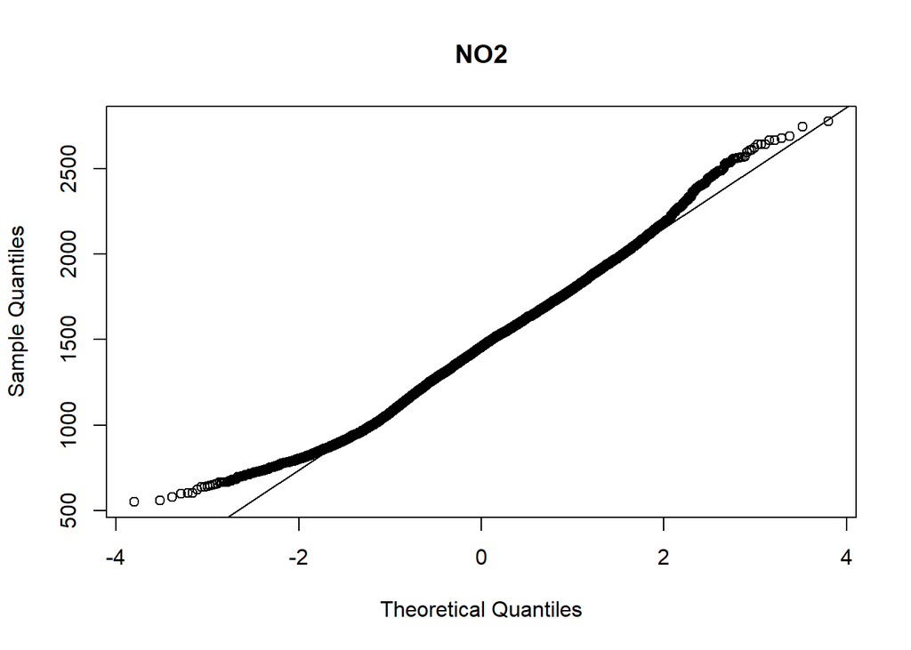

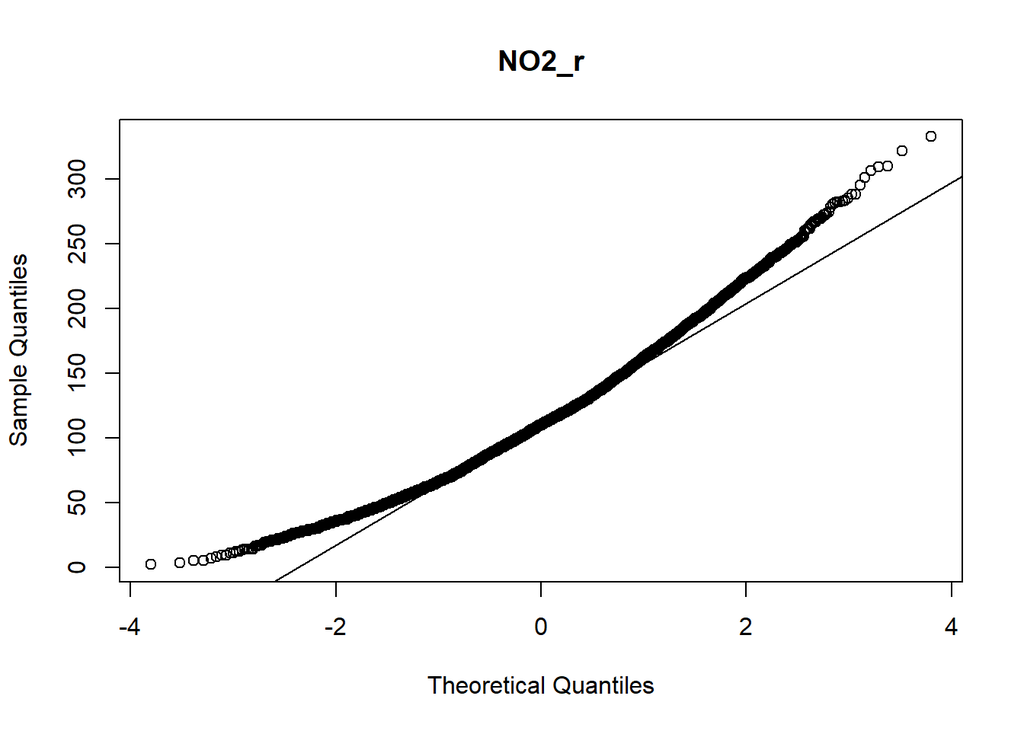

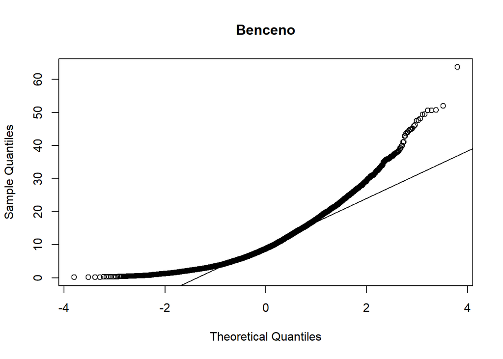

```r
for (columna in colnames(datos_sp_1)){
  qqnorm(datos_sp_1[[columna]], main = columna)
  qqline(datos_sp_1[[columna]])
}
```

En principio, podríamos proponer que estos datos problemáticos se distribuyen como una distribución Gamma, pues esta permite modelar acumulaciones de una cantidad durante un intervalo de tiempo y, en este caso, los registros corresponden a los promedios de una sustancia por hora. Usaremos los métodos visto en clase para comprobarlo. Vamos a definir unas funciones que estaremos mandando a llamar para cada variable.

Para generar la gráfica de Cullen & Frey

```r
library(fitdistrplus)
```

```r
cullenfrey <- function(x){
  descdist(datos_sp_1[[x]], graph = TRUE)
}
```

Y para calcular el AIC para ditintas funciones distribución de probabilidad. En particular, nos enfocaremos en las que vimos en clase y que podemos comparar con el gráfico de Cullen & Frey.

```r
library(dplyr)
library(tibble)
library(univariateML)

calcular_aic <- function(x){

y <- datos_sp_1[[x]]

comparacion_aic <- AIC(
mlbetapr(y),
mlexp(y),
mlgamma(y),
mlunif(y),
mlnorm(y),
mllnorm(y)
)
comparacion_aic %>% rownames_to_column(var = "distribucion") %>%
arrange(AIC)
}
```

### Estimación para CO

Primero para los valores del sensor

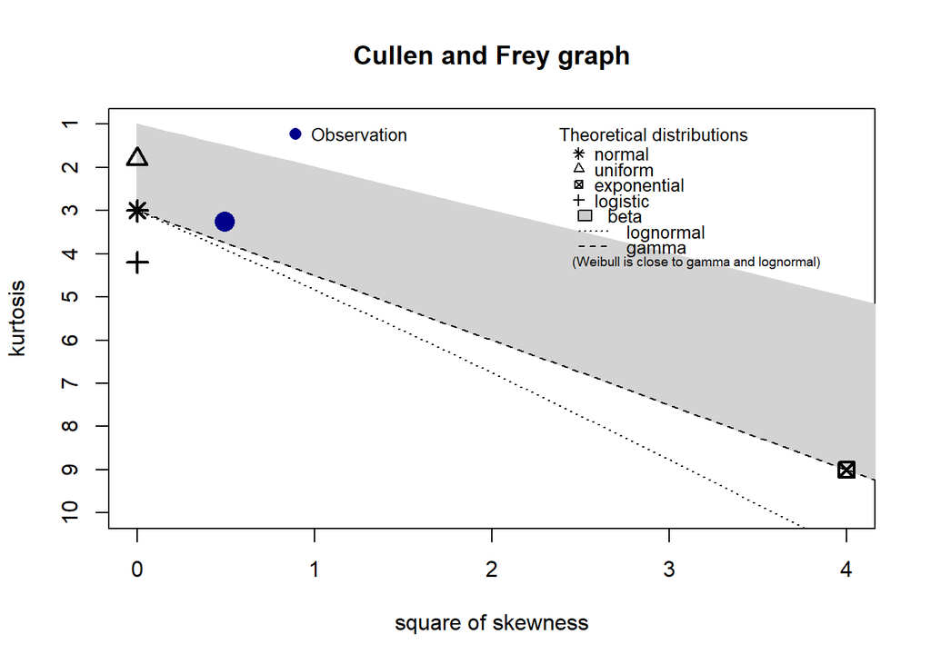

```
## summary statistics
## ------
## min:  647.25   max:  2039.75
## median:  1084.75
## mean:  1119.786
## estimated sd:  218.7391
## estimated skewness:  0.7015475
## estimated kurtosis:  3.258317
```

```r
cullenfrey("CO")
```

```r
calcular_aic("CO")
```

```
##   distribucion df       AIC
## 1  mlbetapr(y)  2  93785.54
## 2   mllnorm(y)  2  93859.43
## 3   mlgamma(y)  2  93999.13
## 4    mlnorm(y)  2  94495.25
## 5    mlunif(y)  2 100493.80
## 6     mlexp(y)  1 111348.04
```

Podemos ver que el método gráfico parece favorecer a una distribución gamma o beta, y al calcular el AIC obtenemos que de hecho la distribución que más se ajusta es una beta.

Vamos a estimar los parámetros con ayuda de la función fitdistr

```r
# Primero escalamos los datos para que estén en el rango [0,1], que son los permitidos para una distribución beta.
datos_escalados <- (datos_sp_1$CO - min(datos_sp_1$CO) + 0.001) / (max(datos_sp_1$CO) - min(datos_sp_1$CO) + 0.002)

# Ahora hacemos la estimación con la función fitdist para encontrar los parámetros alpha y beta
ajustar <- fitdist(datos_escalados, distr = "beta", method = "mle")
alpha <- ajustar$estimate["shape1"]
beta <- ajustar$estimate["shape2"]
print(paste("alpha: ", alpha, "beta:", beta))
```

```
## [1] "alpha:  2.77127000077987 beta: 5.3213922247588"
```

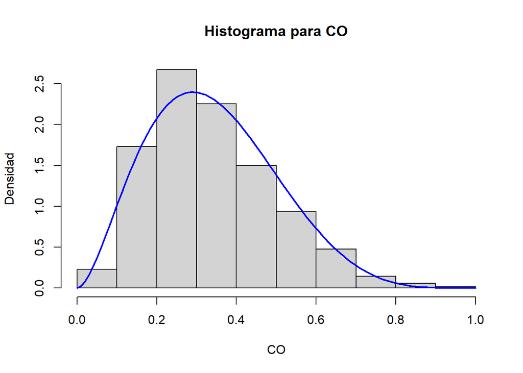

```r
# Generamos los valores de x donde vamos a graficar la función de distribución
x <- seq(min(datos_escalados), max(datos_escalados), length.out = 100)

# Calculamos la función densidad de probabilidad estimada
densidad <- dbeta(x, shape1 = alpha, shape2 = beta)

# Creamos el histograma
hist(datos_escalados, freq = FALSE, xlab = "CO", ylab = "Densidad", main = "Histograma para CO")

# Trazamos la curva de ajuste
lines(x, densidad, col = "blue", lwd = 2)
```

Y ahora para los datos de referencia

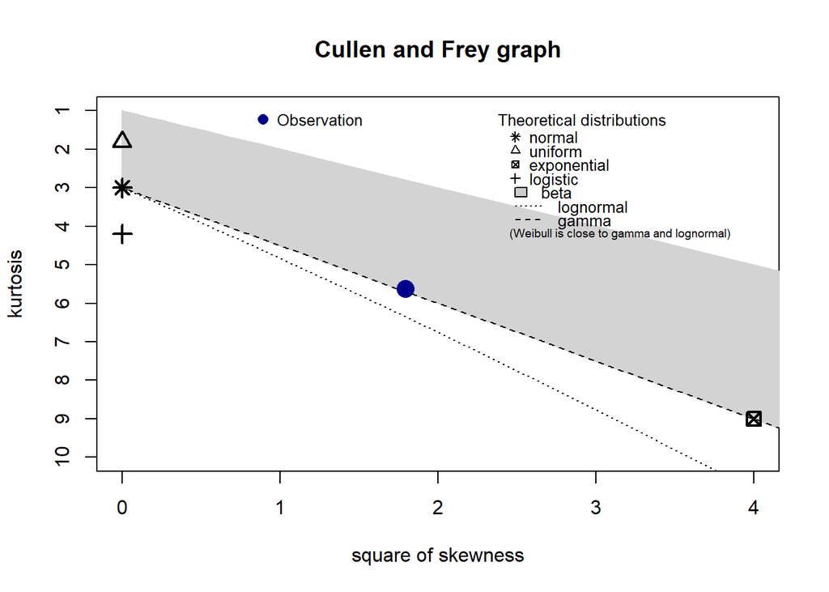

```
## summary statistics
## ------
## min:  0.1   max:  11.9
## median:  1.9
## mean:  2.182467
## estimated sd:  1.441158
## estimated skewness:  1.33915
## estimated kurtosis:  5.620881
```

```r
cullenfrey("CO_r")
```

```r
calcular_aic("CO_r")
```

```
##   distribucion df      AIC
## 1   mlgamma(y)  2 22420.80
## 2   mllnorm(y)  2 22810.90
## 3  mlbetapr(y)  2 22990.51
## 4     mlexp(y)  1 24718.29
## 5    mlnorm(y)  2 24773.84
## 6    mlunif(y)  2 34266.16
```

Como podemos ver en la gráfica, parece ser que efectivamente la distribución Gamma es la más cercana, lo cual es confirmado al calcular el AIC.

Hacemos ahora la estimación:

```r
# Ajustamos la distribución gamma a los datos y estimamos los parámetros
ajustar <- fitdist(datos_sp_1$CO_r, distr = "gamma", method = "mle")
alpha <- ajustar$estimate["shape"]
beta <- ajustar$estimate["rate"]
print(paste("alpha: ", alpha, "beta:", beta))
```

```
## [1] "alpha:  2.34904441624167 beta: 1.07634673368139"
```

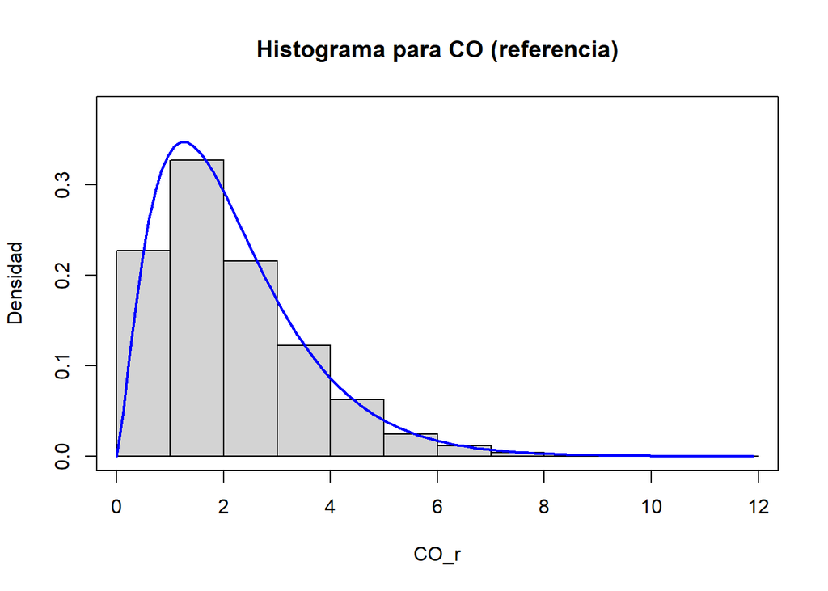

```r
# Generamos secuencia de valores de x
x <- seq(0, max(datos_sp_1$CO_r), length.out = 100)

# Calculamos la función densidad de probabilidad estimada
densidad <- dgamma(x, shape = alpha, rate = beta)

# Gráfica vacía lo suficientemente grande para contener las gráficas
plot(0, 0, type = "n", xlim = range(datos_sp_1$CO_r), ylim = c(0, max(densidad) * 1.1), xlab = "CO_r", ylab = "Densidad", main="Histograma para CO (referencia)")

# Generamos el histograma
hist(datos_sp_1$CO_r, freq = FALSE, add=TRUE)

# Trazamos la curva de ajuste
lines(x, densidad, col = "blue", lwd = 2)
```

### Estimación para NOx

Datos de la estación:

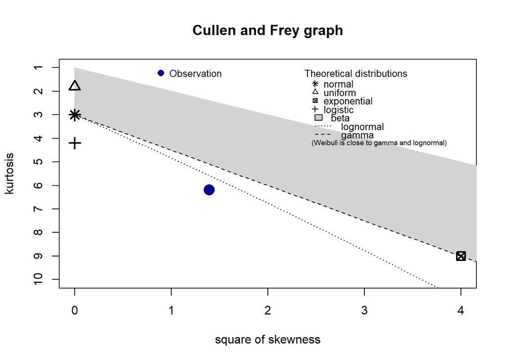

```
## summary statistics
## ------
## min:  322   max:  2682.75
## median:  785.5
## mean:  816.7717
## estimated sd:  251.8968
## estimated skewness:  1.179181
## estimated kurtosis:  6.178194
```

```r
cullenfrey("NOx")
```

```r
calcular_aic("NOx")
```

```
##   distribucion df       AIC
## 1   mllnorm(y)  2  95315.34
## 2  mlbetapr(y)  2  95377.32
## 3   mlgamma(y)  2  95468.95
## 4    mlnorm(y)  2  96454.55
## 5     mlexp(y)  1 106967.80
## 6    mlunif(y)  2 107821.81
```

El método gráfico parece sugerir en este caso una cercanía a la distribución lognormal, lo que se confirma al calcular el AIC. Procedemos a estimar los parámetros.

```r
# Ajustamos la distribución lognormal a los datos y estimamos los parámetros
ajustar <- fitdist(datos_sp_1$NOx, distr = "lnorm", method = "mle")
medialog <- ajustar$estimate["meanlog"]
desviacionlog <- ajustar$estimate["sdlog"]
print(paste("medialog: ", medialog, "sdlog:", desviacionlog))
```

```
## [1] "medialog:  6.66092797761764 sdlog: 0.296993665608918"
```

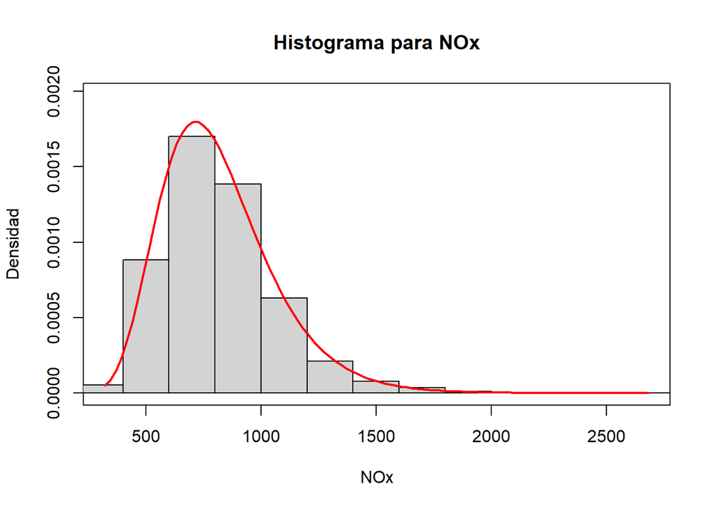

```r
# Generamos secuencia de valores de x
x <- seq(min(datos_sp_1$NOx), max(datos_sp_1$NOx), length.out = 100)

# Calculamos la función densidad de probabilidad estimada con los parámetros que encontramos
densidad <- dlnorm(x, meanlog = medialog, sdlog = desviacionlog)

# Gráfica vacía lo suficientemente grande para contener las gráficas
plot(0, 0, type = "n", xlim = range(datos_sp_1$NOx), ylim = c(0, max(densidad) * 1.1), xlab = "NOx", ylab = "Densidad", main="Histograma para NOx")

# Trazamos el histograma
hist(datos_sp_1$NOx, freq = FALSE, add=TRUE)

# Trazamos la curva de ajuste
lines(x, densidad, col = "red", lwd = 2)
```

Para los datos de referencia:

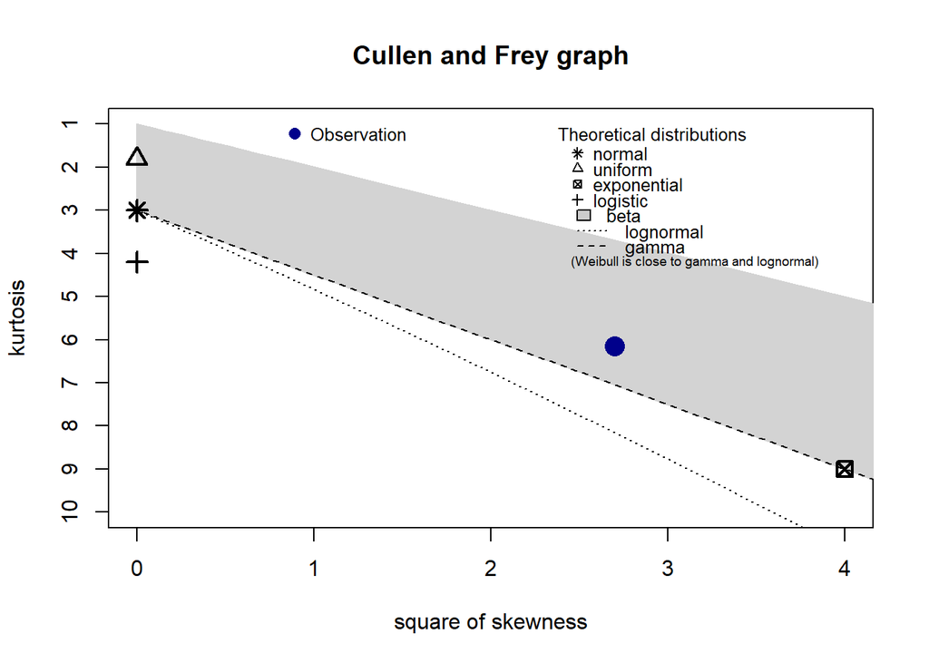

```
## summary statistics
## ------
## min:  2   max:  1479
## median:  186
## mean:  250.6565
## estimated sd:  208.604
## estimated skewness:  1.643631
## estimated kurtosis:  6.155228
```

```r
cullenfrey("NOx_r")
```

```r
calcular_aic("NOx_r")
```

```
##   distribucion df       AIC
## 1   mllnorm(y)  2  89673.24
## 2   mlgamma(y)  2  89693.83
## 3     mlexp(y)  1  90569.33
## 4  mlbetapr(y)  2  91063.12
## 5    mlnorm(y)  2  93836.66
## 6    mlunif(y)  2 101311.62
```

```r
# Ajustamos la distribución lognormal a los datos y estimamos los parámetros
ajustar <- fitdist(datos_sp_1$NOx_r, distr = "lnorm", method = "mle")
medialog <- ajustar$estimate["meanlog"]
desviacionlog <- ajustar$estimate["sdlog"]
print(paste("medialog: ", medialog, "sdlog:", desviacionlog))
```

```
## [1] "medialog:  5.18820287112231 sdlog: 0.862644837560372"
```

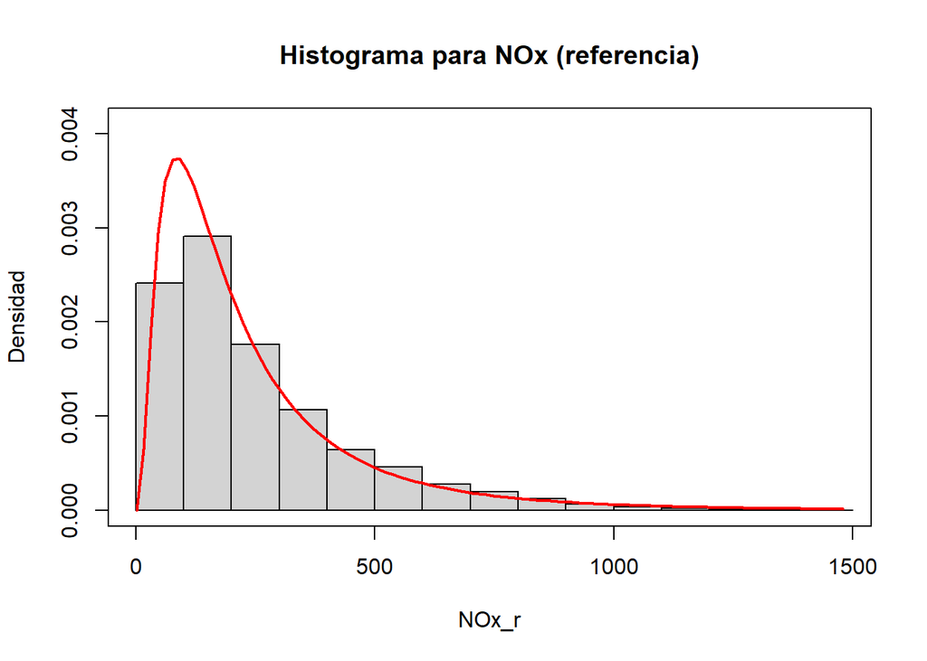

```r
# Generamos secuencia de valores de x
x <- seq(min(datos_sp_1$NOx_r), max(datos_sp_1$NOx_r), length.out = 100)

# Calculamos la función densidad de probabilidad estimada
densidad <- dlnorm(x, meanlog = medialog, sdlog = desviacionlog)

# Gráfica vacía lo suficientemente grande para contener las gráficas
plot(0, 0, type = "n", xlim = range(datos_sp_1$NOx_r), ylim = c(0, max(densidad) * 1.1), xlab = "NOx_r", ylab = "Densidad", main="Histograma para NOx (referencia)")

# Trazamos el histograma
hist(datos_sp_1$NOx_r, freq = FALSE, add = TRUE)

# Trazamos la curva de ajuste
lines(x, densidad, col = "red", lwd = 2)
```

### Estimación para NO2

Para los datos de la estación:

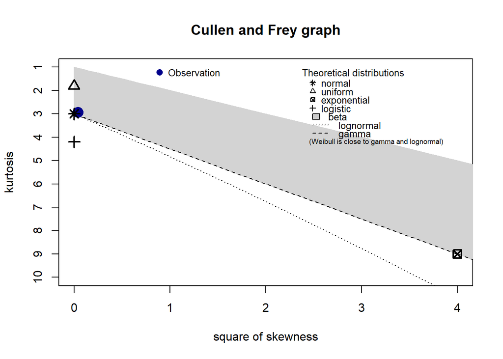

```
## summary statistics
## ------
## min:  551   max:  2775
## median:  1457
## mean:  1452.529
## estimated sd:  353.2979
## estimated skewness:  0.201771
## estimated kurtosis:  2.929611
```

```r
cullenfrey("NO2")
```

```r
calcular_aic("NO2")
```

```
##   distribucion df      AIC
## 1    mlnorm(y)  2 101150.7
## 2   mlgamma(y)  2 101154.9
## 3   mllnorm(y)  2 101358.1
## 4  mlbetapr(y)  2 101694.0
## 5    mlunif(y)  2 106993.4
## 6     mlexp(y)  1 114959.7
```

Tal y como lo supusimos desde la Fase 2, estos datos son los más cercanos a una distribución normal, lo que confirmamos tanto con el método gráfico como con el cálculo del AIC. Vamos a estimar los parámetros de la normal.

```r
# Ajustamos la distribución normal a los datos u estimamos los parámetros
ajustar <- fitdist(datos_sp_1$NO2, distr = "norm", method = "mle")
media <- ajustar$estimate["mean"]
desviacion <- ajustar$estimate["sd"]
print(paste("media: ", media, "sd:", desviacion))
```

```
## [1] "media:  1452.5285981847 sd: 353.272432327552"
```

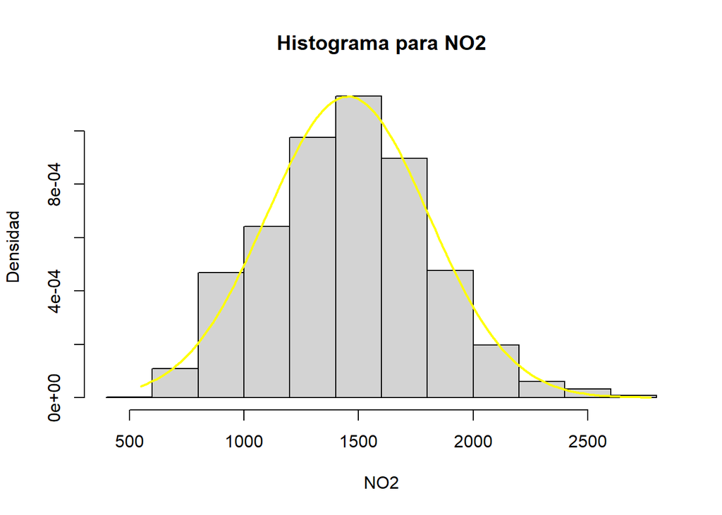

```r
# Generamos secuencia de valores de x
x <- seq(min(datos_sp_1$NO2), max(datos_sp_1$NO2), length.out = 100)

# Calculamos la función densidad de probabilidad estimada
densidad <- dnorm(x, mean = media, sd = desviacion)

# Trazamos el histograma
hist(datos_sp_1$NO2, freq = FALSE, main = "Histograma para NO2", xlab = "NO2", ylab = "Densidad")

# Trazamos la curva de ajuste
lines(x, densidad, col = "yellow", lwd = 2)
```

Y para los datos de referencia:

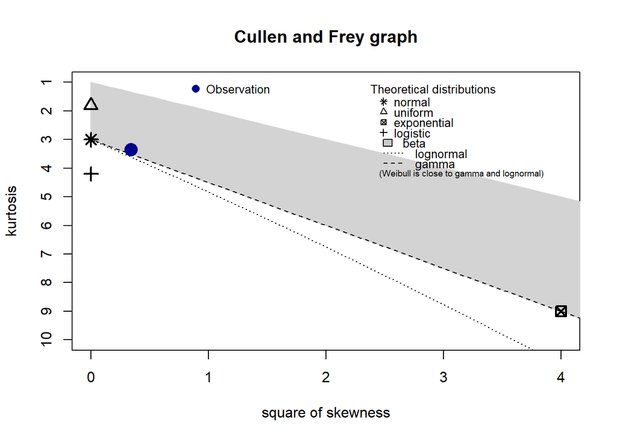

```
## summary statistics
## ------
## min:  2   max:  332.6
## median:  110
## mean:  113.8586
## estimated sd:  47.46471
## estimated skewness:  0.5840824
## estimated kurtosis:  3.342915
```

```r
cullenfrey("NO2_r")
```

```r
calcular_aic("NO2_r")
```

```
##   distribucion df      AIC
## 1   mlgamma(y)  2 72945.00
## 2    mlnorm(y)  2 73285.04
## 3   mllnorm(y)  2 73575.19
## 4  mlbetapr(y)  2 75210.68
## 5     mlexp(y)  1 79614.68
## 6    mlunif(y)  2 80532.22
```

En este caso los datos se aproximan más a una distribución gamma que a una normal. Vamos a estimar sus parámetros.

```r
# Ajustamos la distribución gamma a los datos
ajustar <- fitdist(datos_sp_1$NO2_r, distr = "gamma", method = "mle")
alpha <- ajustar$estimate["shape"]
beta <- ajustar$estimate["rate"]
print(paste("alpha: ", alpha, "beta:", beta))
```

```
## [1] "alpha:  5.29626259676755 beta: 0.0465136733992311"
```

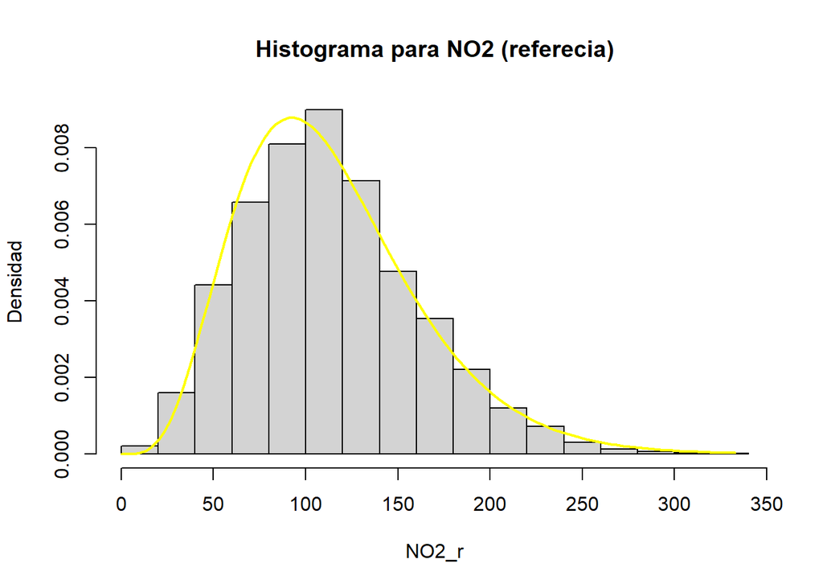

```r
# Generamos secuencia de valores de x
x <- seq(0, max(datos_sp_1$NO2_r), length.out = 100)

# Calculamos la función densidad de probabilidad estimada
densidad <- dgamma(x, shape = alpha, rate = beta)

# Generamos el histograma
hist(datos_sp_1$NO2_r, freq = FALSE, main = "Histograma para NO2 (referecia)", xlab = "NO2_r", ylab = "Densidad")

# Trazamos la curva de ajuste
lines(x, densidad, col = "yellow", lwd = 2)
```

### Estimación para Benceno

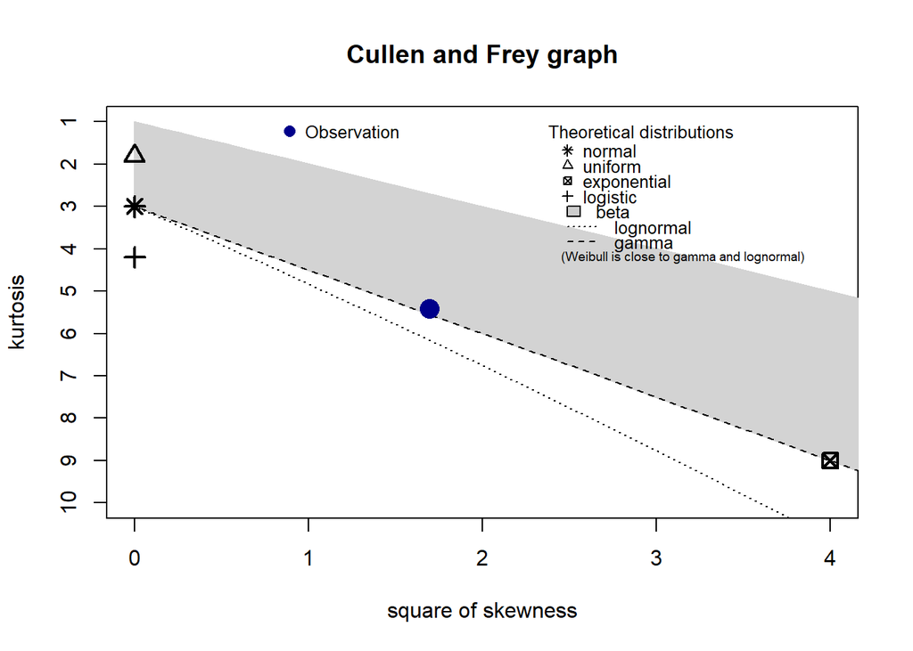

```
## summary statistics
## ------
## min:  0.1815254   max:  63.74148
## median:  8.788282
## mean:  10.55441
## estimated sd:  7.46517
## estimated skewness:  1.301695
## estimated kurtosis:  5.409269
```

```r
cullenfrey("Benceno")
```

```r
calcular_aic("Benceno")
```

```
##   distribucion df      AIC
## 1   mlgamma(y)  2 45042.35
## 2   mllnorm(y)  2 45583.01
## 3     mlexp(y)  1 46597.54
## 4  mlbetapr(y)  2 46711.92
## 5    mlnorm(y)  2 47606.97
## 6    mlunif(y)  2 57641.84
```

El método gráfico parece ajustarse muy bien a una distribución gamma, lo que se confirma con el cálculo del AIC. Vamos a estimar sus parámetros.

```r
# Ajustamos la distribución gamma a los datos
ajustar <- fitdist(datos_sp_1$Benceno, distr = "gamma", method = "mle")
alpha <- ajustar$estimate["shape"]
beta <- ajustar$estimate["rate"]
print(paste("alpha: ", alpha, "beta:", beta))
```

```
## [1] "alpha:  1.97378536990902 beta: 0.187012670055001"
```

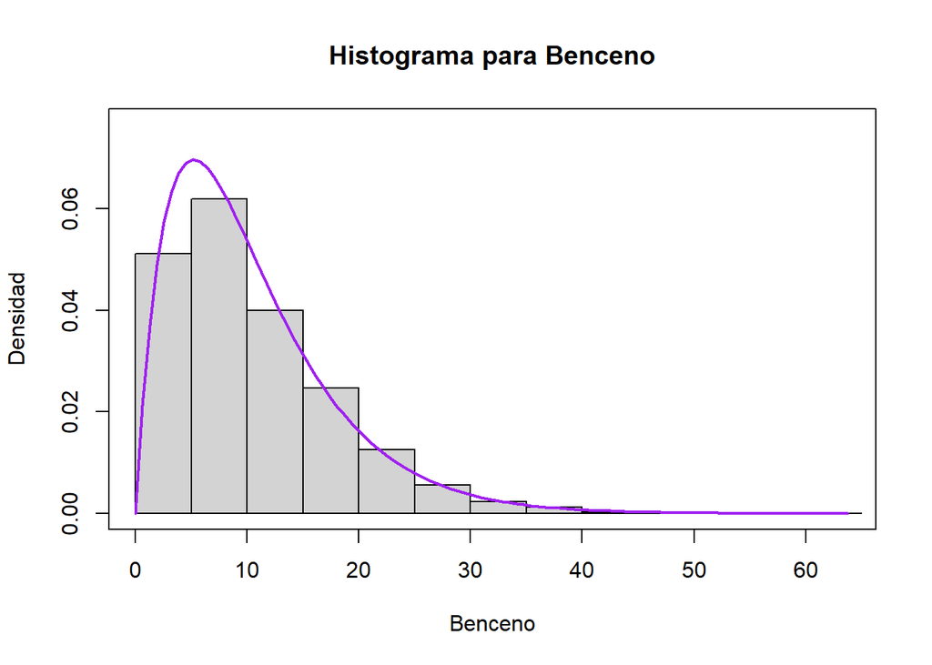

```r
# Generamos secuencia de valores de x
x <- seq(0, max(datos_sp_1$Benceno), length.out = 100)

# Calculamos la función densidad de probabilidad estimada
densidad <- dgamma(x, shape = alpha, rate = beta)

# Gráfica vacía lo suficientemente grande para contener las gráficas
plot(0, 0, type = "n", xlim = range(datos_sp_1$Benceno), ylim = c(0, max(densidad) * 1.1), xlab = "Benceno", ylab = "Densidad", main="Histograma para Benceno")


# Generamos el histograma
hist(datos_sp_1$Benceno, freq = FALSE, add=TRUE,)

# Trazamos la curva de ajuste
lines(x, densidad, col = "purple", lwd = 2, add=TRUE)
```

Finalmente, vamos a aplicar el método Box Cox para intentar transformar las variables para que tengan una distribución normal.

Vamos a almacenar las columnas que vamos a usar como variables independientes. Únicamente lo haremos con los datos de referencia del dataset, pues son los que utilizaremos más adelante.

```r
v_CO <- datos_sp_1$CO_r
v_NOx <- datos_sp_1$NOx_r
v_NO2 <- datos_sp_1$NO2_r
v_benceno <- datos_sp_1$Benceno
```

Veamos los histogramas de nuestros datos originales antes de ser transformados.

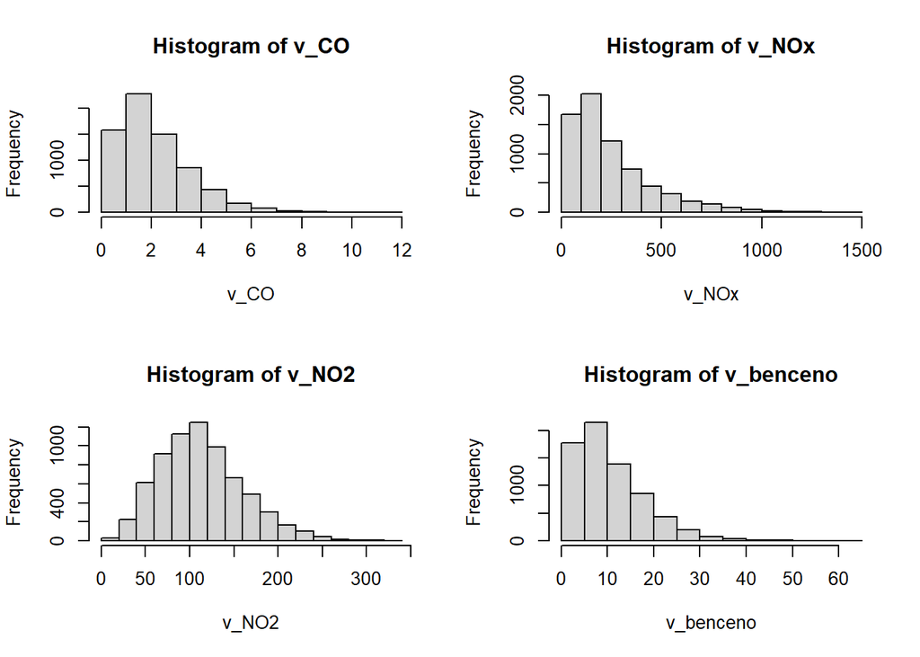

```r
par(mfrow = c(2, 2))
hist(v_CO)
hist(v_NOx)
hist(v_NO2)
hist(v_benceno)
```

Calculamos los lambdas para cada variable

```r
library(forecast)
lambda_benceno = BoxCox.lambda(v_benceno,method="loglik",lower=-20,upper=20)
lambda_co = BoxCox.lambda(v_CO,method="loglik",lower=-20,upper=20)
lambda_nox = BoxCox.lambda(v_NOx,method="loglik",lower=-20,upper=20)
lambda_no2 = BoxCox.lambda(v_NO2,method="loglik",lower=-20,upper=20)
```

Aplicamos las transformaciones y mostramos los nuevos histogramas.

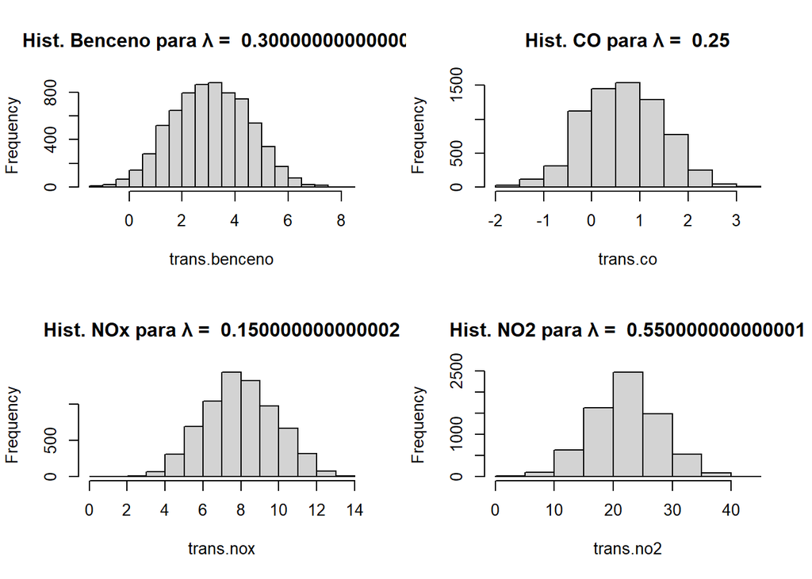

```r
trans.benceno = BoxCox(v_benceno, lambda_benceno)
trans.co = BoxCox(v_CO, lambda_co)
trans.nox = BoxCox(v_NOx, lambda_nox)
trans.no2 = BoxCox(v_NO2, lambda_no2)

par(mfrow = c(2, 2))
hist(trans.benceno, main = paste("Hist. Benceno para λ = ", lambda_benceno))
hist(trans.co, main = paste("Hist. CO para λ = ", lambda_co))
hist(trans.nox, main = paste("Hist. NOx para λ = ", lambda_nox))
hist(trans.no2, main = paste("Hist. NO2 para λ = ", lambda_no2))
```

Nuestras variables de interés ya se parecen más a una distribución normal. Vamos a verificarlo nuevamente con ayuda de la función qqnorm

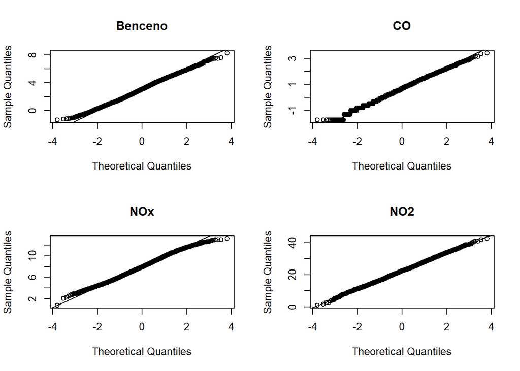

```r
par(mfrow = c(2, 2))
qqnorm(trans.benceno, main = "Benceno")
qqline(trans.benceno)
qqnorm(trans.co, main = "CO")
qqline(trans.co)
qqnorm(trans.nox, main = "NOx")
qqline(trans.nox)
qqnorm(trans.no2, main = "NO2")
qqline(trans.no2)
```

Nuevamente, estamos obteniendo evidencia gráfica favorable de que nuestros datos transformados ya siguen una distribución normal.

### Generación de agrupaciones

Voy a separar los datos de acuerdo a la concentración de Óxidos de Nitrógeno en la atmósfera. Aquellos mayores de una cantitad “t” y los menores iguales a la misma cantidad. En este caso, “t” lo definimos como el promedio de NOx del conjunto de datos.

```r
# Generamos un nuevo dataset con los datos ya transformados.
datos_norm <- data.frame(trans.co, trans.no2, trans.nox, trans.benceno)
colnames(datos_norm) <- c("CO", "NO2", "NOx", "Benceno")

# Definimos el valor de t
t <- mean(datos_norm$NOx)

# Generamos dos nuevos dataframes a partir de t.
datos_menorque <- datos_norm[datos_norm$NOx <= t, ]
datos_mayorque <- datos_norm[datos_norm$NOx > t, ]
```

Intento verificar si es posible estimar la cantidad de Benceno en la atmósfera a partir de las concentraciones de NOx, NO2 y CO. Podemos enunciar la Hipótesis Nula de la siguiente manera.

“Las concentraciones de Benceno permanecen constantes para cualesquiera valores de NOx”

Ahora necesitamos estimar un intervalo del 90% de confianza para comparar el promedio de la variable respuesta (Benceno) entre ambos grupos.

```r
estimacion <- t.test(datos_mayorque$Benceno, datos_menorque$Benceno, alternative = "two.sided", conf.level = 0.9, var.equal = TRUE)
print(estimacion$conf.int)
```

```
## [1] 1.560738 1.655790
## attr(,"conf.level")
## [1] 0.9
```

Es decir, con los datos disponibles podemos decir que la diferencia entre las medias para las concentraciones de Benceno no es igual a cero.

¿Qué suposiciones estamos haciendo? Los datos que usamos son los que ya están transformados, por lo que siguen una distribución normal. Además, los datos son independientes. Después de todo, los registros son mediciones independientes de las concentraciones de Benceno en la estación de referencia. También estamos suponiendo que la varianza en los datos es la misma.

## Modelo de regresión lineal múltiple (Primer modelo)

Hagamos una rápida inspección a las relaciones entre nuestros datos normalizados con ayuda de la función ggpairs de la librería GGally

```r
#install.packages(GGally)
library(GGally)
```

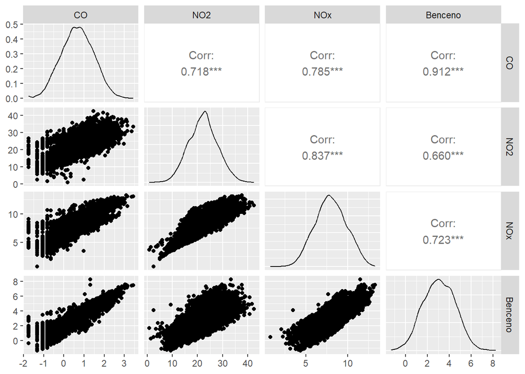

```r
ggpairs(datos_norm)
```

Hay varias cosas importantes que podemos interpretar de aquí.

La variable que tiene mayor correlación con el Benceno es el CO, con un coeficiente de correlación de .912. De hecho, el Benceno parece guardar una alta correlación con todas las variables, siendo el menor coeficiente el .660 del N02, aque aún así sigue siendo de una magnitud importante.

Por otro lado, hay fuertes indicios de correlación entre todas las variables estimadoras, lo cuál podría llegar a ser problemático para nuestro modelo. Sin embargo, es un problema que parece ser inherente a la naturaleza de los datos. ¿Por qué? Porque las variables corresponden a sustancias contaminantes en el aire de una ciudad, por lo que no es raro el suponer que, en los días de mayor polución, las concentraciones de estos contaminantes sea mayor. No estamos haciendo un análisis de la evolución temporal de estas sustancias, sino que queremos estimar la concentración de una de ellas (el Benceno) a partir de las concentraciones de las otras.

Vamos a gener un primer modelo y estudiar su comportamiento.

### Primer modelo

Tomaremos en cuenta todas las variables, es decir, CO, NOx y NO2 para intentar predecir el valor del Benceno.

```r
# Primer estimador lineal para el Benceno
model.benceno1 <- lm(Benceno~CO+NOx+NO2, data = datos_norm)
summary(model.benceno1)
```

```
##
## Call:
## lm(formula = Benceno ~ CO + NOx + NO2, data = datos_norm)
##
## Residuals:
##     Min      1Q  Median      3Q     Max
## -2.4794 -0.3768  0.0265  0.3661  4.1054
##
## Coefficients:
##              Estimate Std. Error t value Pr(>|t|)
## (Intercept) 1.880e+00  4.396e-02  42.764   <2e-16 ***
## CO          1.616e+00  1.459e-02 110.775   <2e-16 ***
## NOx         1.390e-02  8.002e-03   1.737   0.0823 .
## NO2         4.387e-05  2.324e-03   0.019   0.9849
## ---
## Signif. codes:  0 '***' 0.001 '**' 0.01 '*' 0.05 '.' 0.1 ' ' 1
##
## Residual standard error: 0.5947 on 6937 degrees of freedom
## Multiple R-squared:  0.8312, Adjusted R-squared:  0.8311
## F-statistic: 1.139e+04 on 3 and 6937 DF,  p-value: < 2.2e-16
```

Parece ser que, a pesar del problema de la colinealinad, tenemos un valor alto de R^2 de .8311, es decir, el modelo es capaz de explicar el 83.11% de la variabilidad del Benceno.

Por otro lado, obtuvimos p-value: < 2.2e-16, lo que nos indica que hay una fuerte evidencia de que, al menos uno de los coficientes del modelo, no es cero.

El error estándar del modelo es de 0.5947.

Analicemos ahora los coeficientes y sus errores estándar:

- Tanto para el intercepto como para el CO, existe una fuerte evidencia de que son estadísticamente significativos para las concentraciones de Benceno, pues la probabilidad de que tengan una relación nula con la variable respuesta es extremadamente baja (<2e-16)
- En el caso del NOx, la probabilidad de que estos datos tengan una relación nula con la variable de respuesta, es del 8.23%, que es ligeramente superior al 5% que usualmente se busca.
- Finalmente, el modelo indica que hay una alta probabilidad de que las concentraciones de NO2 no sean estadísticamente significativas para la variable de respuesta, específicamente del 98.49%

Veamos ahora los errores estándar de cada coeficiente.

```r
coeficientes <- coef(model.benceno1)  # Coeficientes estimados
std_errors <- sqrt(diag(vcov(model.benceno1)))  # Errores estándar

# Cálculo de los errores porcentuales
errores_porcentuales <- (std_errors / coeficientes) * 100

mostrar_errores <- data.frame(coeficientes, std_errors, errores_porcentuales, check.names = TRUE)
print(mostrar_errores)
```

```
##             coeficientes  std_errors errores_porcentuales
## (Intercept) 1.879966e+00 0.043961392            2.3384147
## CO          1.615969e+00 0.014587903            0.9027342
## NOx         1.390287e-02 0.008001682           57.5541573
## NO2         4.387406e-05 0.002324437         5297.9757363
```

Los errores porcentuales para CO y el Intercepto son relativamente bajos. El coeficiente par NOx tiene un error porcentual importante, del 57.55%. Finalmente, el error porcentual para el coeficiente de NO2 es altísimo, lo que apunta aún más evidencia a que sería mejor retirarlo del modelo.

En el caso del coeficiente de NOx, a pesar del error en el coeficiente, no es recomendable retirarlo, pues de hacerlo el modelo dejaría de ser multivariado. Más aún, tomando en cuenta el análisis que hicimos sobre su error estándar y la baja probabilidad de una relación nula con la variable de respuesta, parecería recomendable mantenerlo modelo final.

En términos de una expresión matemática, la ecuación del modelo sería:

$$B = 1.880 + 1.616 CO + 0.0139NOx +
0.00004387NO2$$

Donde:

- $1.880$ es el intercepto
- $CO$, $NOx$ y $NO2$ representan los valores de las variables independientes.
- $B$ es la variable de respueta, que corresponde a la estimación de la concentración de Benceno.

### Diagnóstico del modelo mediante gráficas

Comenzamos generando las gráficas con ayuda de la función plot

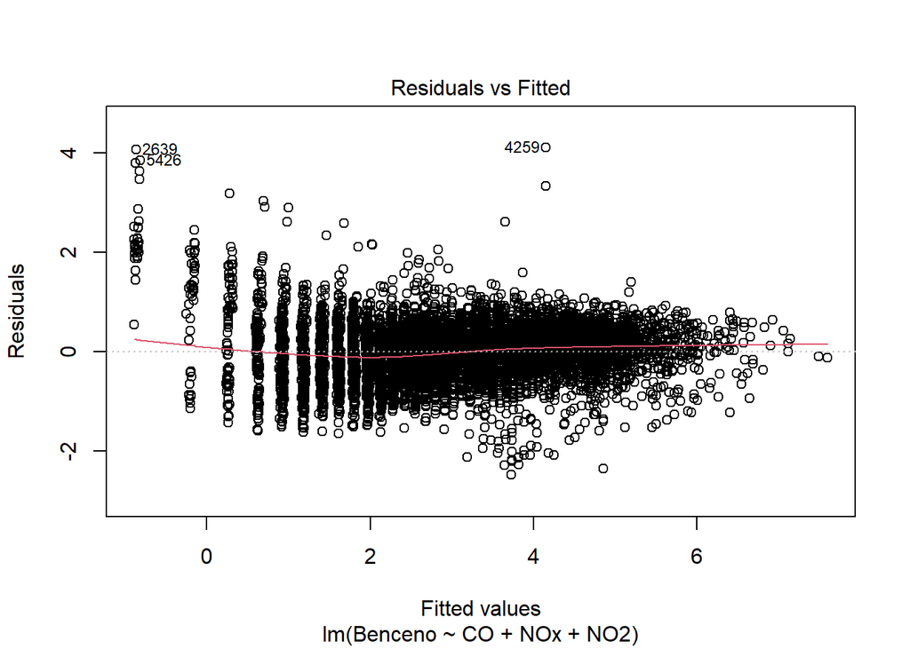

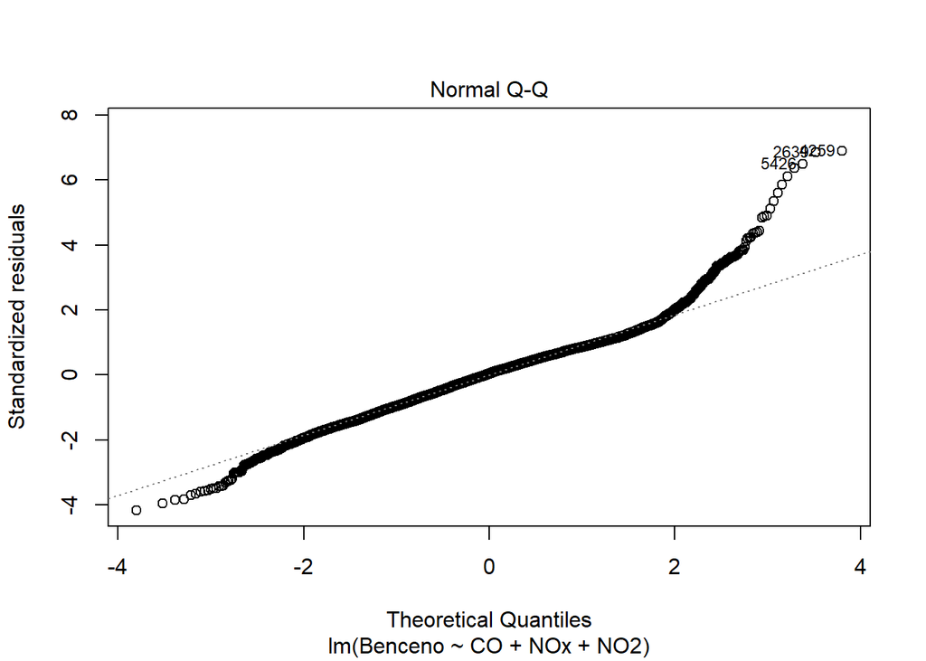

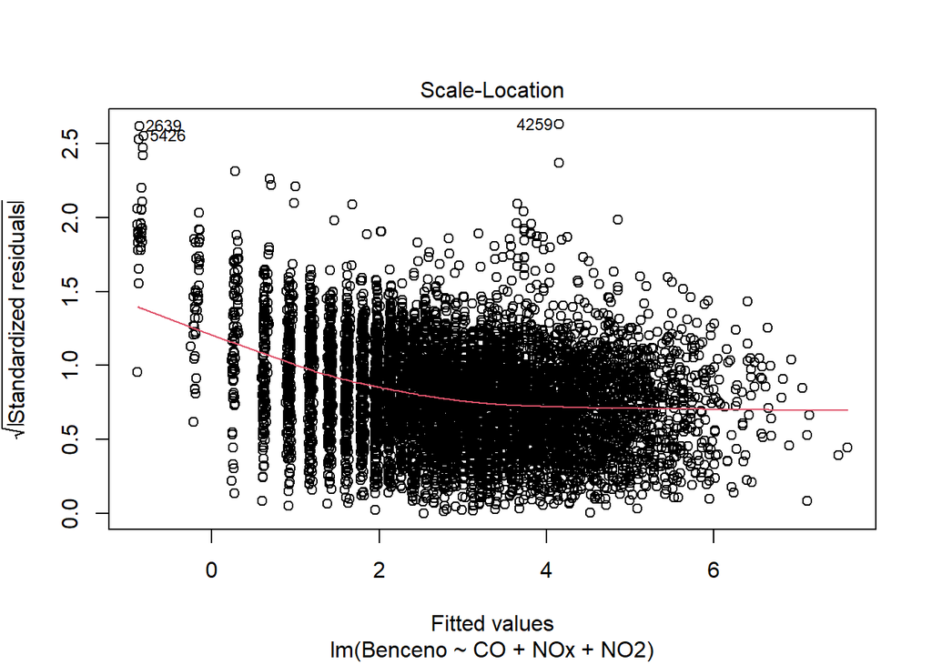

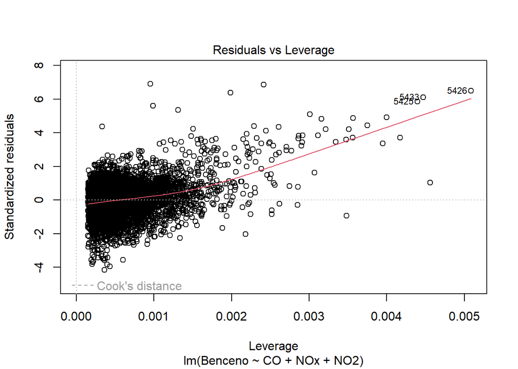

```r
plot(model.benceno1)
```

- En primer gráfica buscamos que los puntos estén distribuidos de forma aleatoria, lo cuál no se cumple pues esiste una patrón distinguible en la dispersión de los puntos.
- En la segunda gráfica queremos comprobar que los residuos siguen una distribución normal. Lo cuál se cumple para la mayoría de los casos, a excepción de los valores extremos.
- En la tercera queremos que los puntos estén aleatoriamente disstribuidos y la linea roja sea lo más horizotal posible. Si bien la línea roja empieza como una curva que va decayendo, poco a poco se va haciendo más horizontal en el extremo derecho.
- En la cuarta gráfica buscamos que todos los residuos se encuentren dentro de la distancia de Cook, lo cuál efectivamente ocurre.

Como podemos ver, este primer modelo tiene varias oportunidades de mejora, a pesar del alto valor de $R^2$ que obtuvimos.